# Coursework Report

*N* removed NAs: 2

*N* removed typo: 1

*N* removed <18: 14

*N* total clean: 133

| Group | *N* | *M*<sub>age</sub> | *M*<sub>rating</sub> |
| --- | --- | --- | --- |
| Control | 69 | 21.19 | 5.43 |
| Experim | 64 | 20.55 | 6.09 |

**Main analysis results**

*t*(131) = -4.66, *p* < .001

[interactive chart not shown]

[figure not shown]

[interactive chart not shown]

# Coursework Report

Analysing Data, Spring 2020

# Methods

## Participants

```
## # A tibble: 2 x 5
##   group  mean    sd   min   max
##   <fct> <dbl> <dbl> <dbl> <dbl>
## 1 White  5.43 0.842     3     7
## 2 Red    6.09 0.797     4     8
```

## Design

The research question for this experiment is ‘does colour influence attractiveness?’.

The independent variable was the colour of the frame in which participants saw a picture of a man. The control group saw a picture in a white frame, whilst the experimental group saw a picture in a red frame. This variable has 2 levels (or factors) of colour condition. We use these factors to interpret the cause of rating scores; the change in colour, we assume, will be the cause of any changes in the dependent variable (ratings).

The dependent variable in this analysis is participant’s ratings of attractiveness when presented with the picture of a man on either a red or white coloured background. Participants were asked to rate on a scale from 1-9 on 3 questions: ‘How attractive do you think this person is?’, ‘How pleasant is this person to look at?’, and ‘If I were to meet the person in this picture face to face, I would think he is attractive.’ The ratings from the 3 questions averaged to get a composite score. The range of rating scale points from 1-9 was created to give participants a wide platform to express their opinion. Ratings from 1-4 for example, don’t give participants much room for questions they may feel neutral or unsure about. We can use the ratings to interpret high and low scores. A rating from 1-3 would be considered a low score, from 4-6 an average score, and from 7-9 a high score. Ratings also prove highly useful when comparing between conditions as we can generate a mean or composite score and easily identify the difference.

The operational hypothesis is ‘Does viewing an image of a man with a different colour frame - either red or white - around him influence participants’ mean ratings of his attractiveness?’ For this study, we will be comparing two means. The statistical analysis we will do to test this is the t-test where t is the difference in sample means compared to the standard error of the differences in means.

# Results

As seen above, the general pattern of results in each condition differs slightly in terms of mean and standard deviation. In the white (control) group, the mean rating of attractiveness was 5.43 whilst in the red (experimental) group, it was 6.09. Despite being a small difference (0.66 rating points), it is still noticeable that participants in the red condition rated the same man as more attractive than those in the white. With regards to standard deviation (SD), there is also a small difference; the white SD was 0.84 and the red was 0.80 when rounded. This tells us that the data in the white group is slightly more widespread than the red, making it slightly less reliable when considering the mean. However, this difference is slight so holds little significance. We can presume that both conditions are widely spread around the mean so both hold questionable reliability.

In terms of changes in data, the participants section outlined the reasons behind removing 17 participants. Additionally, a composite score was generated in order to create data descriptives and the plot (below). This score combined all 3 sets of ratings from each question in the study. To do this, we had to group together the ratings from item_1, item_2, and item_3 for each participant to give them an overall attractiveness rating. This made it easier to compare mean ratings between conditions as there was only one piece of data for each participant.

The statistical test we used was the t-test. This is appropriate to use because it represents the difference in sample means compared to the standard error of the difference in means. In this experiment we have two clear means which we have already found the difference (0.66) so the t-test is a quick method to find out the significance. The t-value in this experiment was -4.6575 (-4.66 rounded). This means there was a significant difference in the mean attractiveness ratings of the red vs white colour groups (Mdiff = 0.66, 95% CI [-0.95, -0.38], t(131) = -4.66), p < 0.001). This equation displays the difference in sample means, the confidence interval of 95%, the degrees of freedom of 131, the p-value of <0.001 and finally the t-value of -4.66. Whilst this value is not particularly high (from 0), it is still a medium level score and is therefore great enough to conclude significance.

This plot (below) illustrates the difference in mean ratings of attractiveness between participants in the white vs red condition. We can immediately notice the difference as the red is plotted slightly higher than the white.

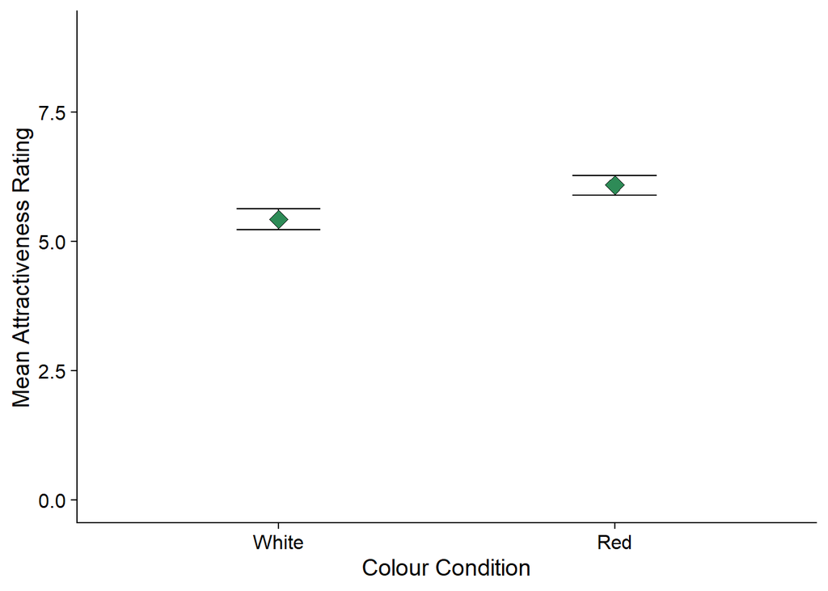

# Discussion

In summary, reverting back to the research question ‘does colour influence attractiveness?’, our results show that colour has influenced attractiveness as the mean rating of attractiveness for the white group is only 5.43 compared to the red which is 6.09 (difference of 0.66). As seen in the results, the t-test score -4.66 highlights that this relationship is significant.

The original study by Elliot et al. (2010) found a red effect in 4 different countries either by changing the colour of the background or the man’s t-shirt. Their first experiment changed the background colour from white to red in each condition and found that participants in the red condition rated the man as more attractive than those in the white. In addition, their other experiments found a similar red effect through for example, changing country from U.S. to English, German or Chinese participants; or changing the colour of the man’s t-shirt to green, blue or grey. With regards to our current study, similar findings were seen. Both the original and present study found a correlation between the colour red and perceptions of attractiveness as they both resulted in participants rating men as more attractive in the red condition than an alternate colour condition. The fact that our study aligns with the original heightens the reliability of our findings as the results are consistent across research.

However, in comparison to other studies, many pieces of research have disproved the red effect. Peperkoorn, Roberts & Pollet’s 2016 study ‘Revisiting the Red Effect on Attractiveness and Sexual Receptivity’ conducted a similar experiment to our’s except they included the colour black (as well as red and white). Participants were assigned a condition where the woman was wearing one of these colours. It was found that ‘participants assigned to the white condition rated the woman as more attractive compared with those in the red and black conditions’, indicating that the woman in red was not deemed most attractive overall. Additionally, ‘the woman in red was not considered to be significantly more sexually attractive than the woman dressed in either black or white’, contrary to the common association between red and heightened sexual receptivity. Therefore, Peperkoorn et al.’s findings do not support our’s as they found no evidence for the red effect. When evaluating our own findings, this causes us to question their reliability as other researchers have not come to the same conclusions we have.

Indeed, it has been accused that the original study (Elliot et al. 2010) is guilty of publication bias and therefore the red effect cannot be certain. Francis’ 2013 article suggests that ‘the probability that the observed 12 findings would all reject the null hypothesis is only .005. Thus, the proper interpretation of the findings is that the studies are contaminated with publication bias.’ He concludes that ‘it remains an open question whether the color red influences women’s ratings of men’s attributes.’ Whilst we know that our own study is not guilty of bias, we feel we must question the reliability of the original study and whether we can use it as a good foundation for our findings. In addition, Hesslinger, Goldbach & Carbon (2015) found no significant impact of red on attractiveness in their studies and found that the style of clothing (formal or casual) had a greater impact. However, in support of our findings, Elliot & Maier (2013) shed light on a number of different studies that have displayed the red effect. For example, ‘the effect was discovered concurrently by S. C. Roberts, Owen, and Havlicek (2010), who, in three experiments, also demonstrated that viewing red on a shirt increases women’s ratings of men’s attractiveness.’

This array of research, the majority disproving the red effect, forces us to question the reliability of our findings as they are inconsistent with a number of studies. Our findings do however still coincide with the original study and several others (as outlined in S. C. Roberts, Owen, and Havlicek’s 2010 paper) so we can trust our results to a high extent. From the diversity of findings in this area, we can propose a great deal more research should be done to clarify the true significance and relationship between the colour red and attractiveness perceptions.

Future studies looking at the red effect could use a wider sample of participants covering a variety of ages, genders, sexualities and cultures. This would help us understand the red effect in more depth with regards to generalisability to the whole population. Elliot et al.’s original study covered a number of nationalities, and included research with both genders. This allowed them to see a trend of the red effect across a wide variety of people and therefore, made their findings much more applicable to the entirety of the population.

In conclusion, returning back to our operational research question, ‘does viewing an image of a man with a different colour frame around him - either red or white - influence participants’ ratings of his attractiveness?’, we have found that the colour of frame does influence attractiveness ratings. Our findings support the original study as both have confirmed the red effect in the sense that red is associated with higher attractiveness perceptions than other colours. Whilst our findings provide a step forward in this area, future research is certainly necessary.

# References

Elliot, A. J., & Maier, M. A. (2013). The red-attractiveness effect, applying the ioannidis and trikalinos (2007b) test, and the broader

scientific context: A reply to francis (2013). *Journal of Experimental Psychology: General, 142*(1), 297-300.

Francis, G. (2013). Publication bias in “Red, rank, and romance in women viewing men,” by elliot et al. (2010). *Journal of Experimental Psychology: General, 142*(1), 292-296.

Hesslinger, V.M., Goldbach, L. & Carbon, C. (2015). Men in red: A reexamination of the red-attractiveness effect. *Psychon Bull Rev 22*, 1142–1148.

Peperkoorn, L.S., Roberts, S.C. & Pollet, T.V. (2016). Revisiting the Red Effect on Attractiveness and Sexual Receptivity: No Effect of the Color Red on Human Mate Preferences. *Evolutionary Psychology 14*(4).